# R Notebook

```r
library(tidyverse)
students <- read.csv("data/students.csv")
```

|  | X | age_years | reaction_time | text_messages_sent_yesterday | favorite_school_subject | school_year | height_cm | sleep_hours_schoolnight | superpower | languages_spoken | planned_education_level |
| --- | --- | --- | --- | --- | --- | --- | --- | --- | --- | --- | --- |
| 1 | 1 | 17 | 0.442 | 45 | English | Year 11 | 185.0 | 8.0 | Telepathy | 1 | Graduate degree |
| 2 | 2 | 14 | 0.394 | 28 | Mathematics and statistics | Year 9 | 160.0 | 7.0 | Invisibility | 2 | Graduate degree |
| 3 | 3 | 14 | 0.551 | 5 | Mathematics and statistics | Year 8 | 152.4 | 6.0 | Telepathy | 1 | Graduate degree |
| 4 | 4 | 17 | 0.355 | 35 | Music | Year 12 | 155.0 | 8.0 | Fly | 1 | High school |
| 5 | 5 | 16 | 0.381 | 15 | Mathematics and statistics | Year 12 | 176.0 | 5.5 | Freeze time | 2 | Less than high school |
| 6 | 6 | 17 | 0.601 | 100 | Physical education | Year 12 | 177.8 | 5.0 | Invisibility | 2 | Graduate degree |

visualise frequency of superpower

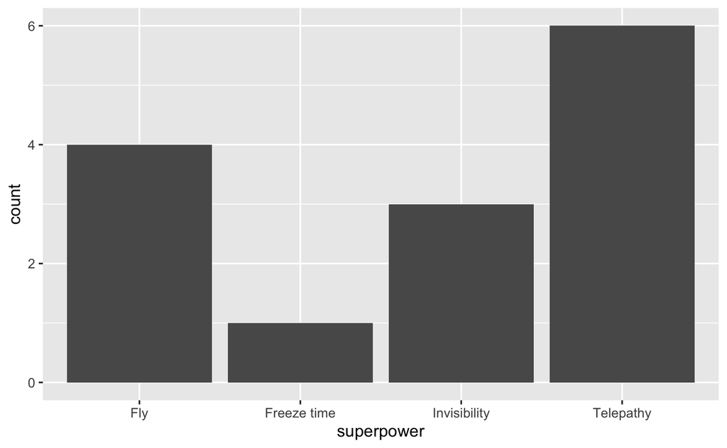

```r
students %>%
  ggplot(aes(x = superpower)) +
  geom_bar()
```

colour?

fill in the geom parts –the main part of the area colour in geom is the outline colour

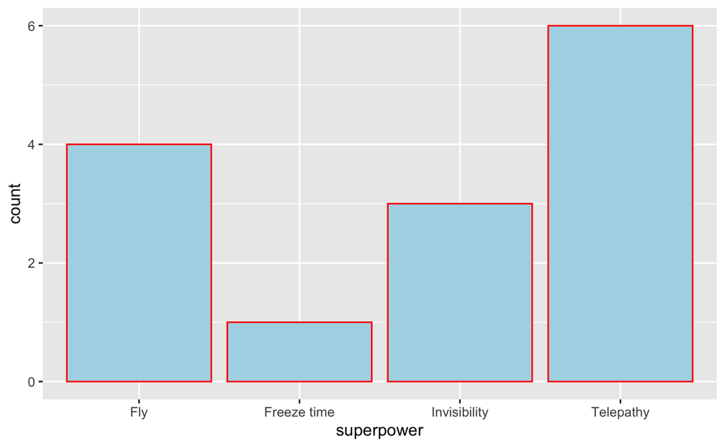

```r
students %>%
  ggplot(aes(x = superpower)) +
  geom_bar(fill = "light blue",
           colour = "red")
```

```r
students %>%
  ggplot(aes(x = superpower,
             fill = school_year)) +
  geom_bar()
```

Position adjustments

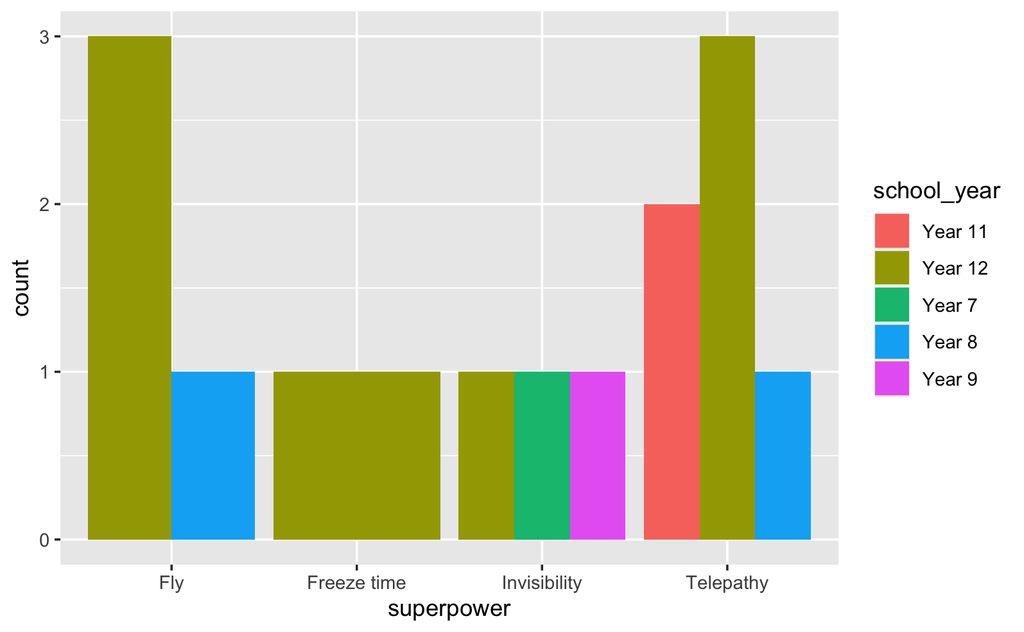

```r
students %>%
  ggplot(aes(x = superpower,
             fill = school_year)) +
  geom_bar(position = "dodge")
```

statistical transformations

```r
students %>%
  ggplot(aes(x = superpower,
             fill = school_year))+
  geom_bar(stat = "count")
```

```r
count_data <- students %>%
  group_by(superpower, school_year) %>%
  summarise(count = n())
```

```r
count_data %>%
  ggplot(aes(x = superpower, y = count, fill = school_year)) +
  geom_bar(stat = "identity")
```

```r
count_data %>%
  ggplot(aes(x = superpower, y = count, fill = school_year)) +
  geom_col()
```

labels for new lines

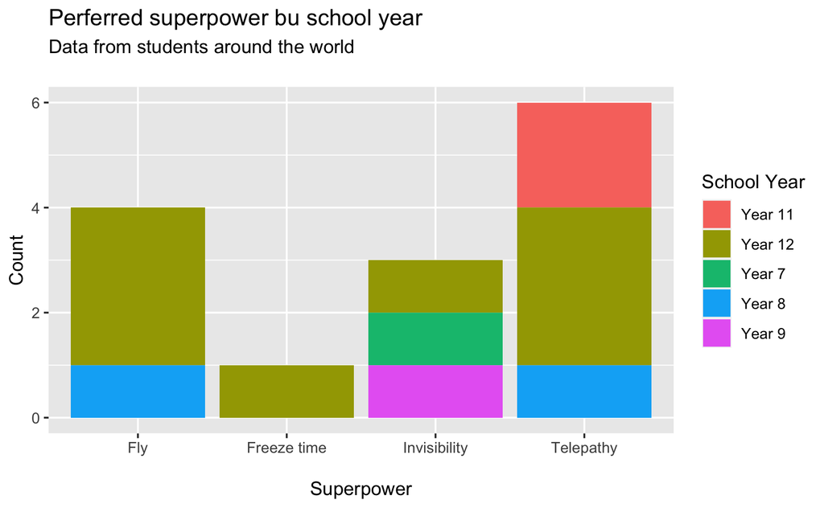

```r
students %>%
  ggplot(aes(x = superpower,
             fill = school_year)) +
  geom_bar() +
  labs(x = "\nSuperpower",
       y = "Count",
       title = "Perferred superpower bu school year",
       subtitle = "Data from students around the world\n",
       fill = "School Year")
```

```r
NA
```

```r
olympic <- read_csv("data/olympics_overall_medals.csv")
top_10 <- olympic %>%
  filter(season == "Summer", medal == "Gold") %>%
  arrange(desc(count)) %>%
  top_n(10)
top_10
```

| team | season | medal | count |
| --- | --- | --- | --- |
| United States | Summer | Gold | 2333 |
| Soviet Union | Summer | Gold | 830 |
| Germany | Summer | Gold | 564 |
| Italy | Summer | Gold | 492 |
| Great Britain | Summer | Gold | 481 |
| Hungary | Summer | Gold | 432 |
| France | Summer | Gold | 421 |
| East Germany | Summer | Gold | 337 |
| Australia | Summer | Gold | 336 |
| Sweden | Summer | Gold | 326 |

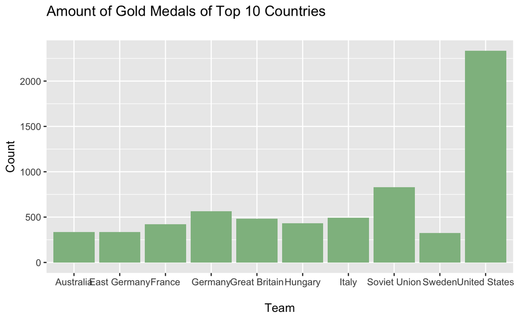

```r
top_10 %>%
  ggplot(aes(x= team, y = count))+
  geom_col(fill =  "dark sea green")+
   labs(x = "\nTeam",
       y = "Count",
       title = "Amount of Gold Medals of Top 10 Countries\n")
```

```r
#this following graph shows the top 10 gold medal wining countries.
#US has a lot higher amount of gold medals compared to other countries
```

layers

```r
library(janitor)
```

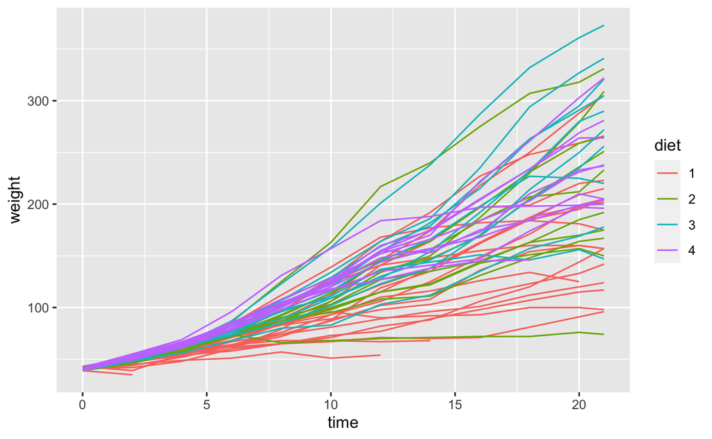

```r
chick_weight %>%
  ggplot(aes(x=time,
             y= weight,
             group = chick,
             colour = diet))+
  geom_line()
```

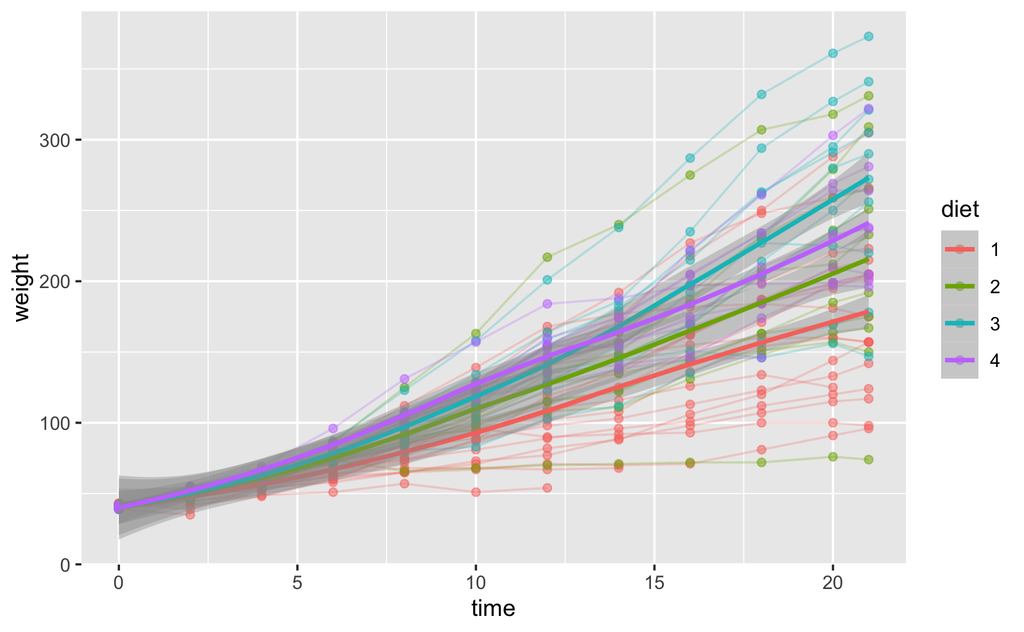

```r
chick_weight %>%
  ggplot(aes(x=time,
             y= weight,
             colour = diet
             ))+
  geom_line(aes(group = chick),
            alpha = 0.25) +
  geom_point( alpha = 0.5) +
  geom_smooth()
```

Go back to using the students dataset:

1,Use geom_point to make a scatter graph, with the height of students on the x-axis and their reaction time of the y axis.

2,Make all the points blue. For geom_bar, the colour of the bar is controlled by fill, but for geom_point the colour of the points are controlled by colour.

3,Make the colour of the points depend on the superpower the student wishes they had.

4,Write down what the graph tells you overall.

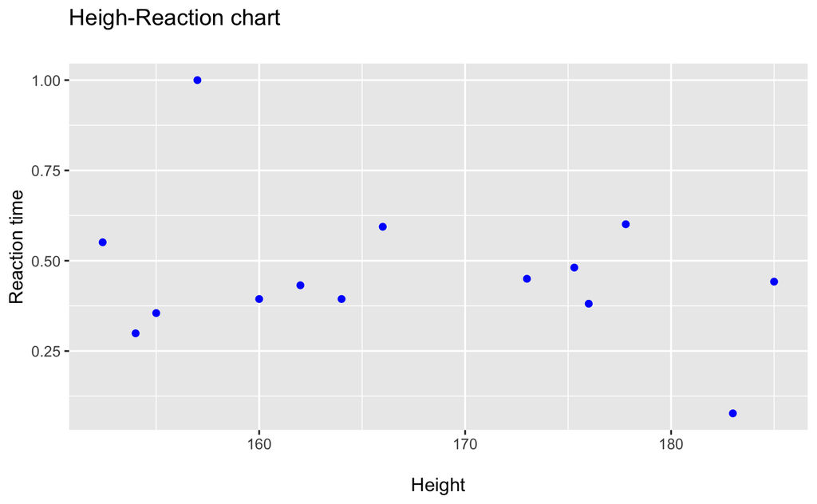

```r
students %>%
  ggplot(aes(x = height_cm,
         y = reaction_time
         ))+
  geom_point(colour = "blue")+
  labs(x = "\nHeight",
       y = "Reaction time",
       title = "Heigh-Reaction chart\n")
```

```r
#No correlations here, everyone seems to have similar reaction time
```

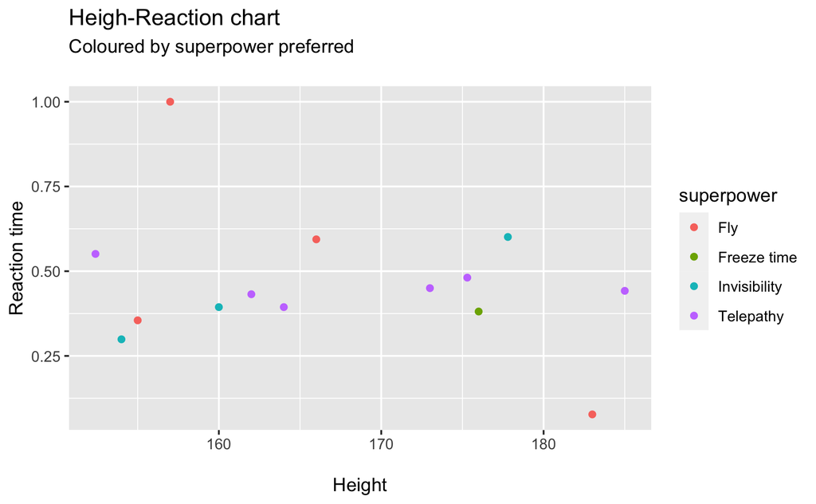

```r
students %>%
  ggplot(aes(x = height_cm,
         y = reaction_time,
         colour = superpower))+
  geom_point()+
    labs(x = "\nHeight",
       y = "Reaction time",
       title = "Heigh-Reaction chart",
       fill = "Superpower",
       subtitle = "Coloured by superpower preferred\n")
```

```r
pets <- read_csv("data/pets.csv")
```

Create a labelled scatter plot, of pet age vs. weight, with the following 5 mapping/aesthetics. For items 3-5 you may want to look at the help file of ?geom_point and read about different aesthetics:

1.We want age on the x-axis and weight on the y axis 2.We want the points to be different colours depending on the gender of the pet 3.We want different shapes depending on the type of animal 4.We want all the points to be bigger than normal (size 4). 5.We also want labels with the pets names next to every point.

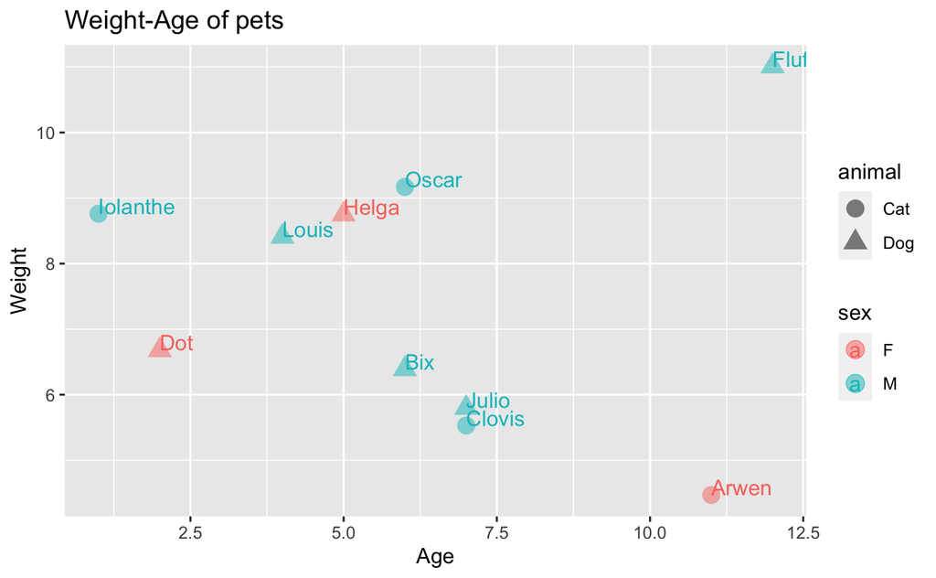

```r
pets %>%
  ggplot(aes(x = age,
         y = weight,
         colour = sex
         ))+
  geom_point(aes(shape = animal),
             alpha = 0.5,
             size = 4) +
  geom_text(aes(label = name),
            hjust=0, vjust=0)+
  labs(x = "Age",
       y = "Weight",
       title = "Weight-Age of pets")
```

setting will not have a key on the side and if i do mapping than it will have a key

```r
ggsave("g1_save.png")
```